# Interactive data visualization

GEOG 30323

November 7, 2017

## Interactive visualization

- Thus far: you’ve learned how to create static charts with `pandas` and `seaborn`
- Our focus now turns to *interactive charts*

### Data storytelling

[video not shown]

### Data journalism

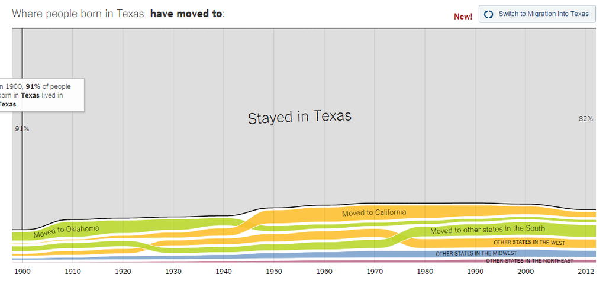

Source: *The New York Times*

### Interactive visualization and the web

- Analytical workflows have become increasingly connected to the web - or even completely web-based
- Interactive data visualization: graphics not just *on* the web, but *of* the web

### The past: Java and Flash

[figure not shown]

[figure not shown]

### The present: HTML5 and JavaScript

[figure not shown]

[figure not shown]

- Examples: http://d3js.org/

### The future: WebGL

[interactive chart not shown]

Source: Mapzen

### Why interactive visualization?

- User is an *active participant* rather than a *passive observer*
- Key points to consider:
  - What are you visualizing?
  - What is the purpose of your visualization?
  - Who is your audience?
  - In what format and venue will you be presenting the visualization?

### New libraries!

- We’re going to usesome new Python libraries to chart interactively. They include:
  - `ipywidgets`: a package for interactive mini-apps in the Jupyter Notebook
  - `plotly`: produces D3.js charts using Python, and can convert your Python charts as well
  - `cufflinks`: binds `pandas` to `plotly`
- In CoCalc, interactivity only available in the **Classical Notebook**: change the format to get this code to work

### Let’s get some data!

```python
import pandas as pd
import seaborn as sns
import matplotlib.pyplot as plt

mx = pd.read_csv('http://personal.tcu.edu/kylewalker/mexico.csv')
```

### Our basic plot

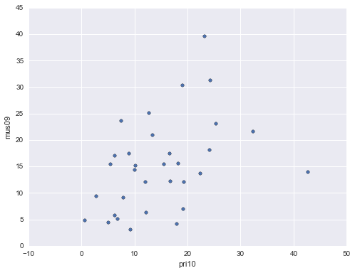

```python
mx.plot(kind = 'scatter', x = 'pri10', y = 'mus09')
```

### Interactivity in the Notebook

- In CoCalc: interactivity requires the **Classical** rather than the **Modern** notebook
- Use the command `%matplotlib notebook`, and your plot becomes interactive!

```python
%matplotlib notebook
mx.plot(kind = 'scatter', x = 'pri10', y = 'mus09')
```

### Interactivity in the Notebook

- The `ipywidgets` package allows you to build basic graphical user interfaces (GUIs) to explore your data in the Notebook
- How it works: supply a function to the `interact` function in `ipywidgets`

```python
from ipywidgets import interact

def add_five(x):
    print(x + 5)

interact(add_five, x = (1, 100))
```

## Interactivity with plots

```python
cols = ['mus09', 'pri10', 'sec10', 'ter10', 'gdp08']

def make_plot(x, y, title):
    sns.lmplot(data = mx, x = x, y = y)
    plt.title(title)

interact(make_plot, x = cols, y = cols, title = "Enter a plot title!")
```

### Widgets: not just for plots!

```python
def get_accidents(street_name):
    part1 = 'https://data.fortworthtexas.gov/resource/kr8h-9zxd.json?streetname='
    api_call = part1 + street_name
    return pd.read_json(api_call)

def get_street(street = ['BERRY', 'UNIVERSITY', 'ROSEDALE']):
    df = get_accidents(street)
    return df.head()

interact(get_street)
```

### Plotly

- Plotly: Web-based platform for interactive charting;
- Includes both offline components (works in the Jupyter Notebook) and an online cloud/web GUI at https://plot.ly/

### Plotly in Python

- The Plotly Python package can convert your `matplotlib` plots to Plotly charts!

```python
import plotly.offline as py
py.init_notebook_mode()

mx.plot(kind = 'scatter', x = 'pri10', y = 'mus09')
fig = plt.gcf() # "Get current figure"
py.iplot_mpl(fig)
```

### Plotly and `seaborn`

- Plotly can convert some `seaborn` plots - though the styling will not always carry over

```python
sns.distplot(mx.pri10)
f = plt.gcf()
py.iplot_mpl(f)
```

## Cufflinks

- New Python library to create Plotly plots directly from `pandas` data frames!
- Simply use `iplot` instead of `plot`!

```python
import cufflinks as cf
cf.go_offline()

mx.iplot(kind = 'scatter', mode = 'markers', x = 'pri10',
         y = 'mus09', text = 'name', colors = 'green',
         xTitle = '% of workforce in primary sector',
         yTitle = 'Out-migration rate to the United States')
```

## Cufflinks

```python
mx[['pri10', 'gdp08', 'mus09']].scatter_matrix()
```

## Cufflinks!

```python
mx.iplot(kind = 'scatter3d', x = 'mus09', y = 'gdp08',
         z = 'pri10', mode = 'markers', text = 'name')
```

## The Plotly cloud

- Plotly plots are fully editable and saveable in the cloud if you have a Plotly account; click “Export to plot.ly” on your chart
- Demo

## Plotly.py

- More advanced visualizations can be developed with the Plotly Python library
- How it works: specify a list of graph objects to be plotted, along with layout options (optional) to customize the chart appearance; supply to the `iplot()` function to view in the Jupyter Notebook

## 3-dimensional plots

```python
import numpy as np
import plotly.graph_objs as go

arr = np.random.randn(10, 10)

data = [go.Surface(z = arr)]

py.iplot(data)
```

### Widgets and range sliders

- Step 1: Get the data

```python
from pandas_datareader import wb

ind = "SP.DYN.TFRT.IN"

tfr = wb.download(country = "all", indicator = ind, start = 1960, end = 2013)

tfr.reset_index(inplace = True)
```

### Widgets and range sliders

- Step 2: build the plotting function

```python
def tfr_plot(country1, country2, country3):
    countries = [country1, country2, country3]
    subset = tfr[tfr.country.isin(countries)]
    subset_wide = subset.pivot(index = "year", columns = "country",
                               values = "SP.DYN.TFRT.IN")
    plot_data = [
        go.Scatter(x = subset_wide.index,
                  y = subset_wide[country],
                  name = country,
                  mode = "lines")
        for country in countries
    ]
    plot_layout = go.Layout(title = "Total fertility rate",
                           xaxis = dict(rangeslider = dict()),
                           yaxis = dict(title = "TFR"))
    fig = dict(data = plot_data, layout = plot_layout)
    py.iplot(fig)
```

### Widgets and range sliders

- Step 3: interact with the plot

```python
country_list = list(tfr.country.unique())

interact(tfr_plot, country1 = country_list,
         country2 = country_list, country3 = country_list)
```

## Saving your plots

- If you have a Plotly account, you can save plots with the default styling to Plotly’s cloud by clicking “Export to plot.ly”
- Otherwise: plots can be saved as standalone HTML outside of the notebook

### Saving your plots (cufflinks example)

```python
myplot = mx.iplot(kind = 'scatter', mode = 'markers', x = 'pri10',
         y = 'mus09', text = 'name', colors = 'green',
         xTitle = '% of workforce in primary sector',
         yTitle = 'Out-migration rate to the United States',
         asFigure = True)

py.plot(myplot, filename = 'mexico_plot.html')
```